# Análisis base DIGES

Florencia Gayraud

2023-12-11

# 1 Análisis descriptivo variables de interés

```r
library(readxl)
library(tidyverse)
library(kableExtra)
base <- read_excel("C:/Users/Florencia Gayraud/Desktop/Clases Derecho y Políticas Públicas/proyecto diges/SPG DIGES Base de datos version 1.0.xlsx")
```

## 1.1 Cantidad de sentencias

```r
base %>%
  group_by(pais) %>%
  summarise(Cantidad = n()) %>%
  arrange(Cantidad) %>%
  kable() %>%
  kable_paper(bootstrap_options = "striped", full_width = F)
```

| pais | Cantidad |
| --- | --- |
| Argentina | 39 |
| Perú | 77 |
| Chile | 85 |
| México | 129 |

## 1.2 Evolución por año de cantidad de sentencias

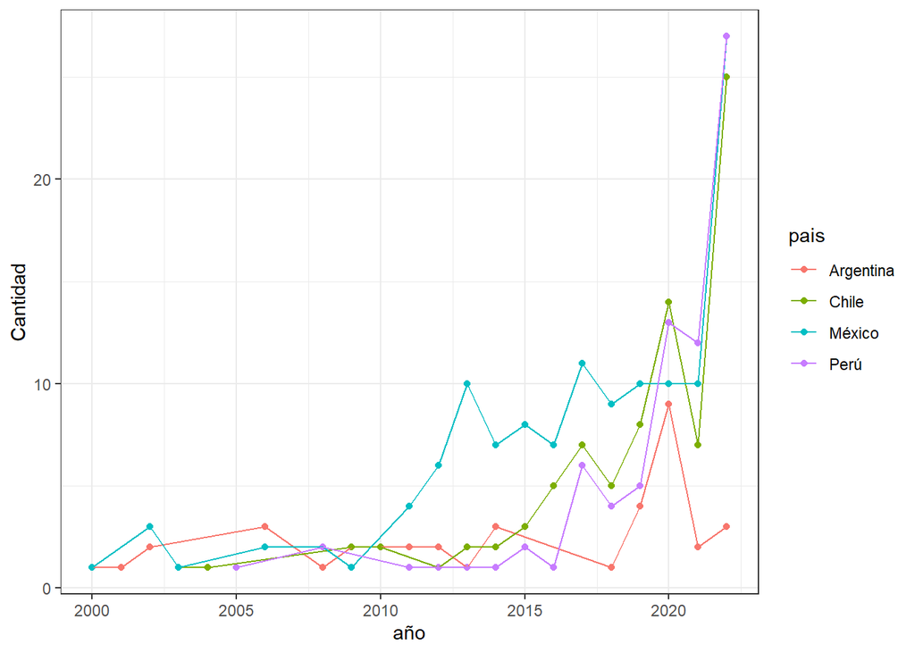

```r
evol <- base %>%
  mutate(año=substr(fecha, 1,4)) %>%
  group_by(pais, año) %>%
  summarise(Cantidad = n())
evol$año <- as.numeric(evol$año)
ggplot(evol, aes(x=año, y=Cantidad, color=pais)) +
  geom_point() +
  geom_line() +
  theme_bw()
```

Como era de esperar la cantidad de sentencias crece con el tiempo. El pico de México tiene coherencia con el primer protocolo.

## 1.3 Dimensiones

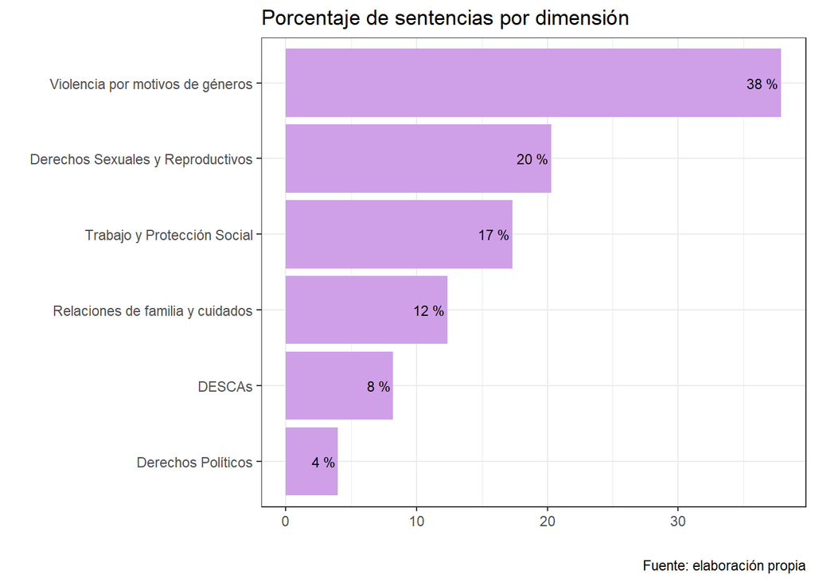

```r
dimensiones <- base %>%
  separate_rows(dimension, sep = ", ") %>%
  group_by(dimension) %>%
  summarise(cantidad=n()) %>%
  mutate(porcentaje = (cantidad / sum(cantidad)) * 100) %>%
  arrange(porcentaje)

ggplot(dimensiones) +
  geom_col(aes(x=reorder(dimension, porcentaje), y=porcentaje), fill = "#cfa0e8") +
  geom_text(aes(x=dimension, y=porcentaje, label = paste(round(porcentaje, digits = 0), "%")),
            hjust = 1.1, , size = 3) +
  coord_flip() +
  theme_bw() +
  labs(x="", y="",
       title = "Porcentaje de sentencias por dimensión",
       caption = "Fuente: elaboración propia")
```

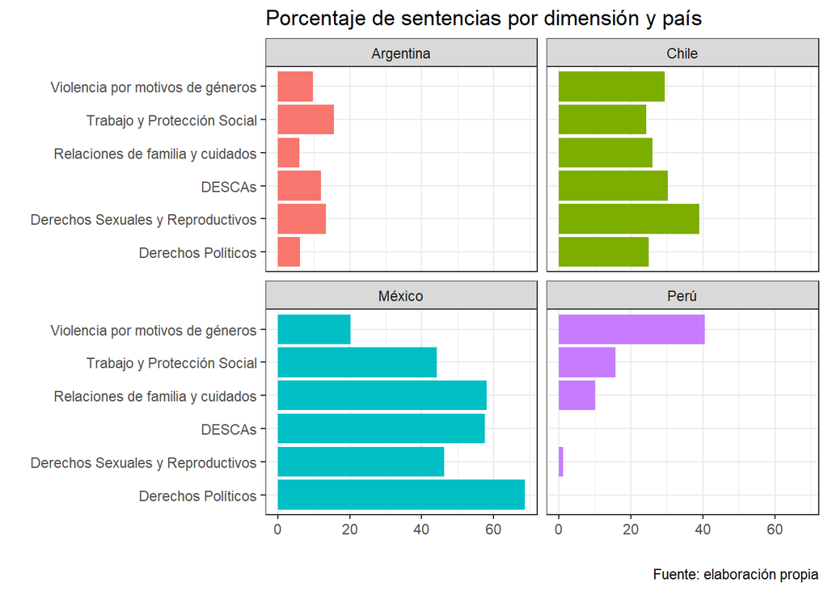

```r
dimensiones_pais <- base %>%
  separate_rows(dimension, sep = ", ") %>%
  group_by(dimension, pais) %>%
  summarise(cantidad=n()) %>%
  mutate(porcentaje = (cantidad / sum(cantidad)) * 100) %>%
  arrange(porcentaje)

ggplot(dimensiones_pais) +
  geom_col(aes(x=dimension, y=porcentaje, fill=pais)) +
  #geom_text(aes(x=dimension, y=porcentaje, label = paste(round(porcentaje, digits = 0), "%")),
   #         hjust = 1.1, , size = 3) +
  facet_wrap(~pais) +
  coord_flip() +
  theme_bw() +
  labs(x="", y="",
       title = "Porcentaje de sentencias por dimensión y país",
       caption = "Fuente: elaboración propia") +
  theme(legend.position = "none")
```

## 1.4 Palabras claves

```r
palabras <- base %>%
  separate_rows(palabras_claves, sep = ", ") %>%
  group_by(palabras_claves) %>%
  summarise(cantidad=n())
```

159 valores únicos, se puede ver de agrupar

## 1.5 Materia

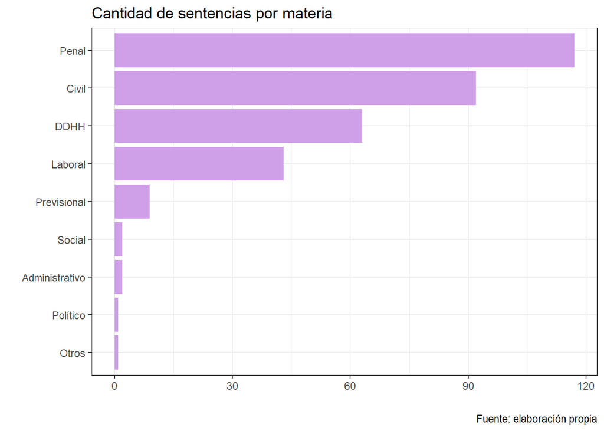

```r
base %>%
  group_by(materia) %>%
  summarise(Cantidad = n()) %>%
  ggplot() +
  geom_col(aes(x=reorder(materia, Cantidad), y=Cantidad), fill = "#cfa0e8") +
  theme_bw() +
  coord_flip() +
  labs(x="", y="",
       title = "Cantidad de sentencias por materia",
       caption = "Fuente: elaboración propia")
```

## 1.6 Tipo de caso

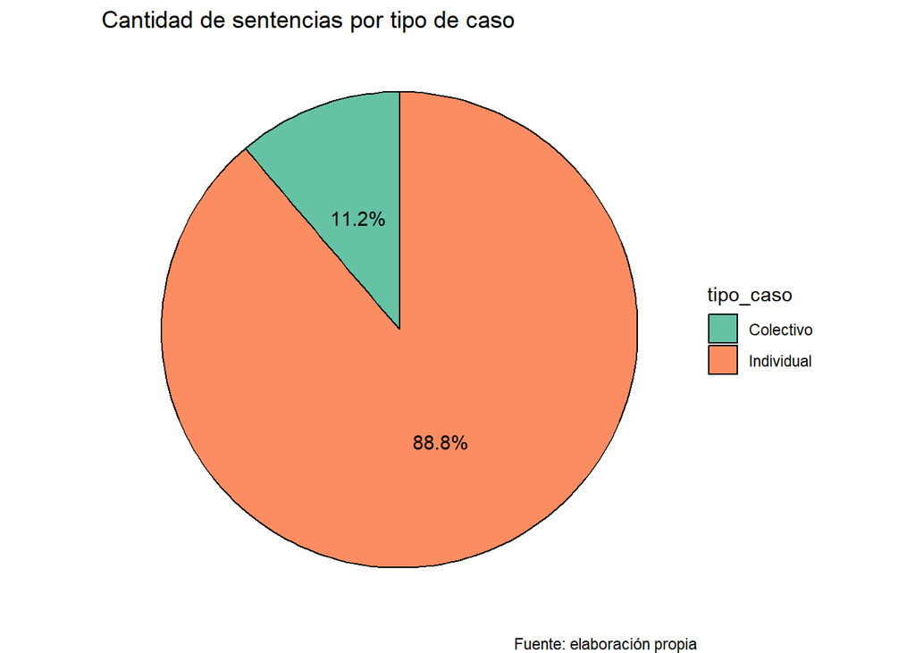

```r
base %>%
  group_by(tipo_caso) %>%
  summarise(Cantidad = n()) %>%
  mutate(Porcentaje = (Cantidad / sum(Cantidad)) * 100) %>%
  ggplot(aes(x="", y=Cantidad, fill=tipo_caso, label=sprintf("%.1f%%", Porcentaje))) +
  geom_bar(stat="identity", width=1, color="black") +
  geom_text(position = position_stack(vjust = 0.5)) +
  coord_polar("y", start=0) +
  theme_void() +
  scale_fill_brewer(palette="Set2") +
  labs(x="", y="",
       title = "Cantidad de sentencias por tipo de caso",
       caption = "Fuente: elaboración propia")
```

## 1.7 Perfil demandante

¿Hay un perfil de demandante? (perfil_demandante)

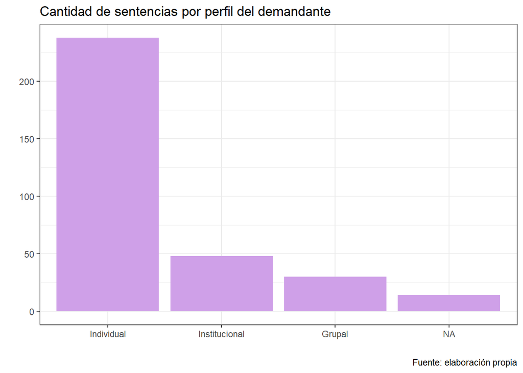

```r
base %>%
  group_by(perfil_demandante) %>%
  summarise(Cantidad = n()) %>%
  ggplot(aes(x=reorder(perfil_demandante, -Cantidad), y=Cantidad)) +
  geom_col(fill = "#cfa0e8") +
  theme_bw() +
  labs(x="", y="",
       title = "Cantidad de sentencias por perfil del demandante",
       caption = "Fuente: elaboración propia")
```

## 1.8 parte_demandante_indiv

¿Predominan las ONGs?

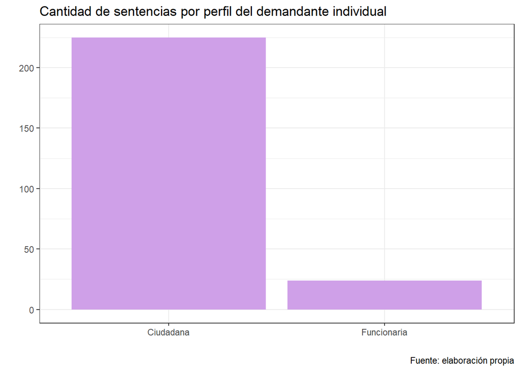

```r
base %>%
  filter(!is.na(parte_demandante_indiv)) %>%
  group_by(parte_demandante_indiv) %>%
  summarise(Cantidad=n()) %>%
  ggplot(aes(x=reorder(parte_demandante_indiv, -Cantidad), y=Cantidad)) +
  geom_col(fill = "#cfa0e8") +
  theme_bw() +
  labs(x="", y="",
       title = "Cantidad de sentencias por perfil del demandante individual",
       caption = "Fuente: elaboración propia")
```

## 1.9 abogado_parte_demandante

¿Los abogados son particulares o no?

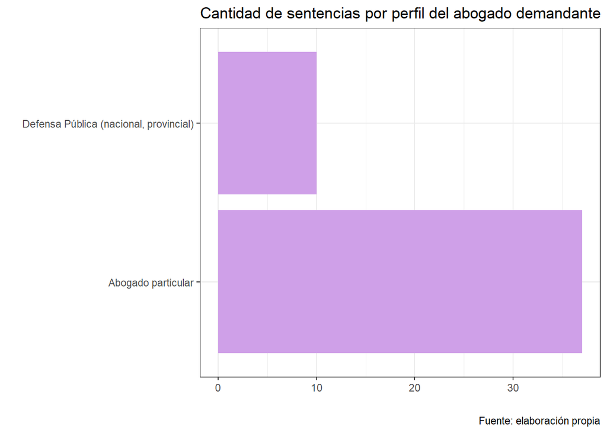

```r
base %>%
  filter(!is.na(abogado_parte_demandante)) %>%
  group_by(abogado_parte_demandante) %>%
  summarise(Cantidad=n()) %>%
  ggplot(aes(x=reorder(abogado_parte_demandante, -Cantidad), y=Cantidad)) +
  geom_col(fill = "#cfa0e8") +
  theme_bw() +
  labs(x="", y="",
       title = "Cantidad de sentencias por perfil del abogado demandante",
       caption = "Fuente: elaboración propia") +
  coord_flip()
```

## 1.10 Beneficio

Carácter del remedio

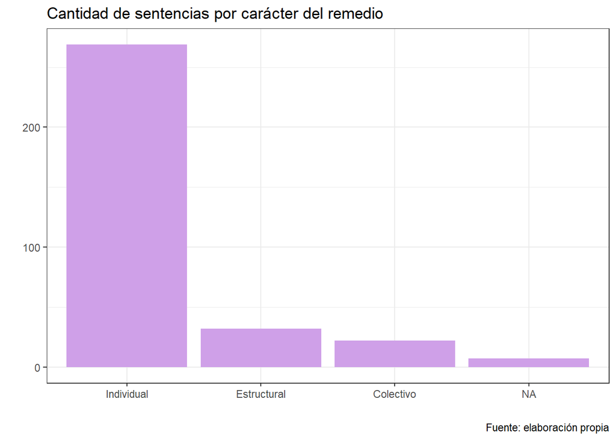

```r
base %>%
  group_by(caracter_remedio) %>%
  summarise(Cantidad=n()) %>%
  ggplot(aes(x=reorder(caracter_remedio, -Cantidad), y=Cantidad)) +
  geom_col(fill = "#cfa0e8") +
  theme_bw() +
  labs(x="", y="",
       title = "Cantidad de sentencias por carácter del remedio",
       caption = "Fuente: elaboración propia")
```

## 1.11 ¿Quiénes se benefician más allá de la perspectiva?

Ver el carácter del remedio y si hay relación entre el efecto y el tipo de remedio + ¿Hay competencia exclusiva según el carácter?

```r
base %>%
  group_by(caracter_remedio, remedios) %>%
  summarise(Cantidad=n())%>%
  arrange(-Cantidad) %>%
  kable() %>%
  kable_paper(bootstrap_options = "striped", full_width = F)
```

| caracter_remedio | remedios | Cantidad |
| --- | --- | --- |
| Individual | Rechaza | 81 |
| Individual | Prestación no económica | 55 |
| Individual | Exhortación a otras autoridades | 53 |
| Individual | Prestación económica | 27 |
| Estructural | Prestación no económica | 20 |
| Individual | Sobre competencia | 14 |
| Individual | Restitución de cosas al estado anterior | 13 |
| Colectivo | Rechaza | 9 |
| Individual | Exhortación a otras autoridades, Prestación económica, Prestación no económica | 6 |
| Estructural | Rechaza | 4 |
| Individual | Medida cautelar | 4 |
| NA | No aplica | 4 |
| Colectivo | Prestación no económica | 3 |
| Colectivo | Sobre competencia, Rechaza | 3 |
| Estructural | Exhortación a otras autoridades | 3 |
| Estructural | Restitución de cosas al estado anterior | 3 |
| Individual | Rechaza, Exhortación a otras autoridades | 3 |
| Colectivo | Exhortación a otras autoridades | 2 |
| Colectivo | Prestación económica | 2 |
| Colectivo | Restitución de cosas al estado anterior | 2 |
| Individual | Prestación no económica, Prestación económica | 2 |
| Individual | Restitución de las cosas al estado anterior | 2 |
| NA | Rechaza | 2 |
| Colectivo | Exhortación a otras autoridades, Prestación económica, Prestación no económica | 1 |
| Estructural | No aplica | 1 |
| Estructural | Sobre competencia | 1 |
| Individual | Confirma la sentencia apelada | 1 |
| Individual | Confirma sentencia cámara apelaciones de valdivia | 1 |
| Individual | Exhortación a otras autoridades, prestacion economica | 1 |
| Individual | Exhotacion a otras autoridades | 1 |
| Individual | Prestacion economica, Exhortación a otras autoridades | 1 |
| Individual | Prestación económica, Exhortación a otras autoridades | 1 |
| Individual | Prestación no económica, Compensación | 1 |
| Individual | Prestación no económica, Exhortación a otras autoridades | 1 |
| Individual | Rechaza, Exhortación a otras autoridades, Prestación económica, Prestación no económica, Compensación | 1 |
| NA | Rechaza, Sobre competencia | 1 |

## 1.12 Relación entre estructural (caracter_remedio) vs casos de violencia (dimension)

```r
base %>%
  filter(caracter_remedio=="Estructural") %>%
  group_by(dimension) %>%
  summarise(Cantidad=n()) %>%
  arrange(-Cantidad) %>%
  kable() %>%
  kable_paper(bootstrap_options = "striped", full_width = F)
```

| dimension | Cantidad |
| --- | --- |
| Derechos Sexuales y Reproductivos | 13 |
| Derechos Políticos | 5 |
| Relaciones de familia y cuidados | 3 |
| Trabajo y Protección Social | 3 |
| Trabajo y Protección Social, DESCAs | 3 |
| Violencia por motivos de géneros | 3 |
| DESCAs | 1 |
| Derechos Sexuales y Reproductivos, Violencia por motivos de géneros | 1 |

32 casos donde predominan Derechos Sexuales y Reproductivos.

De aquellos que son remedios estructurales veamos a que país corresponde

```r
base %>%
  filter(caracter_remedio=="Estructural") %>%
  group_by(pais) %>%
  summarise(cantidad = n())%>%
  arrange(-cantidad) %>%
  kable() %>%
  kable_paper(bootstrap_options = "striped", full_width = F)
```

| pais | cantidad |
| --- | --- |
| México | 28 |
| Perú | 3 |
| Argentina | 1 |

Y de aquellos que son colectivos vemos:

```r
base %>%
  filter(caracter_remedio=="Colectivo") %>%
  group_by(pais) %>%
  summarise(cantidad = n())%>%
  arrange(-cantidad) %>%
  kable() %>%
  kable_paper(bootstrap_options = "striped", full_width = F)
```

| pais | cantidad |
| --- | --- |
| México | 17 |
| Argentina | 3 |
| Chile | 1 |
| Perú | 1 |

Lo que si ocurre es que la mayoría de los remedios individuales son sobre Violencia por motivos de géneros

```r
base %>%
  filter(caracter_remedio=="Individual") %>%
  group_by(dimension) %>%
  summarise(Cantidad=n()) %>%
  arrange(-Cantidad) %>%
  kable() %>%
  kable_paper(bootstrap_options = "striped", full_width = F)
```

| dimension | Cantidad |
| --- | --- |
| Violencia por motivos de géneros | 101 |
| Trabajo y Protección Social | 43 |
| Derechos Sexuales y Reproductivos | 32 |
| Relaciones de familia y cuidados | 15 |
| DESCAs | 12 |
| Violencia por motivos de géneros, Derechos Sexuales y Reproductivos | 9 |
| Violencia por motivos de géneros, Relaciones de familia y cuidados | 9 |
| Derechos Sexuales y Reproductivos, Violencia por motivos de géneros | 8 |
| Relaciones de familia y cuidados, DESCAs | 5 |
| Relaciones de familia y cuidados, Trabajo y Protección Social | 5 |
| Trabajo y Protección Social, Violencia por motivos de géneros | 4 |
| Relaciones de familia y cuidados, Violencia por motivos de géneros | 3 |
| Trabajo y Protección Social, DESCAs | 3 |
| Violencia por motivos de géneros, Trabajo y Protección Social | 3 |
| Derechos Políticos | 2 |
| Derechos Políticos, Violencia por motivos de géneros | 2 |
| Derechos Sexuales y Reproductivos, Relaciones de familia y cuidados | 2 |
| Trabajo y Protección Social, Relaciones de familia y cuidados | 2 |
| Violencia por motivos de géneros, DESCAs | 2 |
| DESCAs, Trabajo y Protección Social | 1 |
| DESCAs, Violencia por motivos de géneros, Relaciones de familia y cuidados | 1 |
| Derechos Políticos, DESCAs | 1 |
| Derechos Políticos, Derechos Sexuales y Reproductivos | 1 |
| Derechos Sexuales y Reproductivos, DESCAs | 1 |
| Derechos Sexuales y Reproductivos, Derechos Políticos | 1 |
| Derechos Sexuales y Reproductivos, Trabajo y Protección Social | 1 |

## 1.13 Variable orientacion_decision

Nos habla del resguardo y la garantía de los derechos de las mujeres, si es a favor o en contra

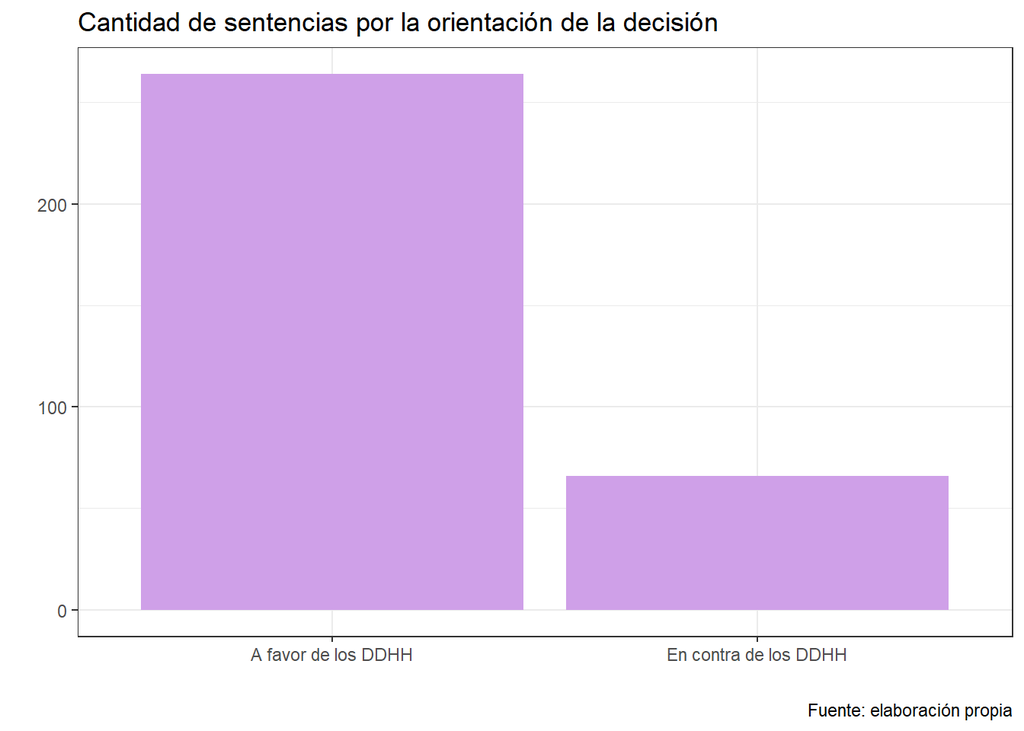

```r
base %>%
  group_by(orientacion_decision) %>%
  summarise(Cantidad=n()) %>%
  ggplot(aes(x=reorder(orientacion_decision, -Cantidad), y=Cantidad)) +
  geom_col(fill = "#cfa0e8") +
  theme_bw() +
  labs(x="", y="",
       title = "Cantidad de sentencias por la orientación de la decisión",
       caption = "Fuente: elaboración propia")
```

Como era de esperar la mayoría de las decisiones es en favor de los derechos de las mujeres y colectivo LGTBIQ+

## 1.14 genero_explicito

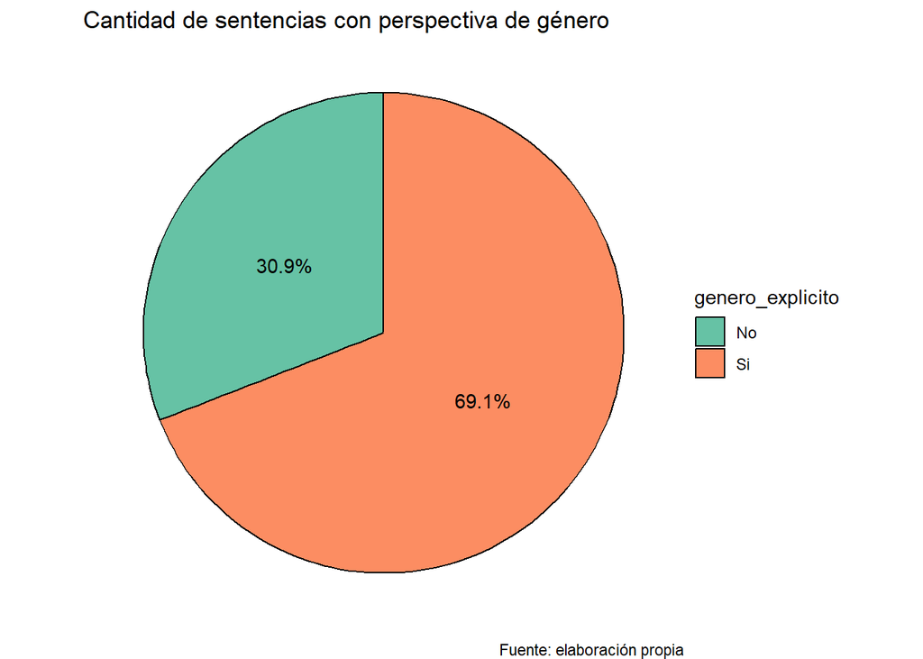

```r
base %>%
  group_by(genero_explicito) %>%
  summarise(Cantidad = n()) %>%
  mutate(Porcentaje = (Cantidad / sum(Cantidad)) * 100) %>%
  ggplot(aes(x="", y=Cantidad, fill=genero_explicito, label=sprintf("%.1f%%", Porcentaje))) +
  geom_bar(stat="identity", width=1, color="black") +
  geom_text(position = position_stack(vjust = 0.5)) +
  coord_polar("y", start=0) +
  theme_void() +
  scale_fill_brewer(palette="Set2") +
  labs(x="", y="",
       title = "Cantidad de sentencias con perspectiva de género",
       caption = "Fuente: elaboración propia")
```

El 80% de las sentencias son a favor de los DDHH, sin embargo el 69% de los casos tienen perspectiva de género. Veamos el submundo a favor de los DDHH qué pasa:

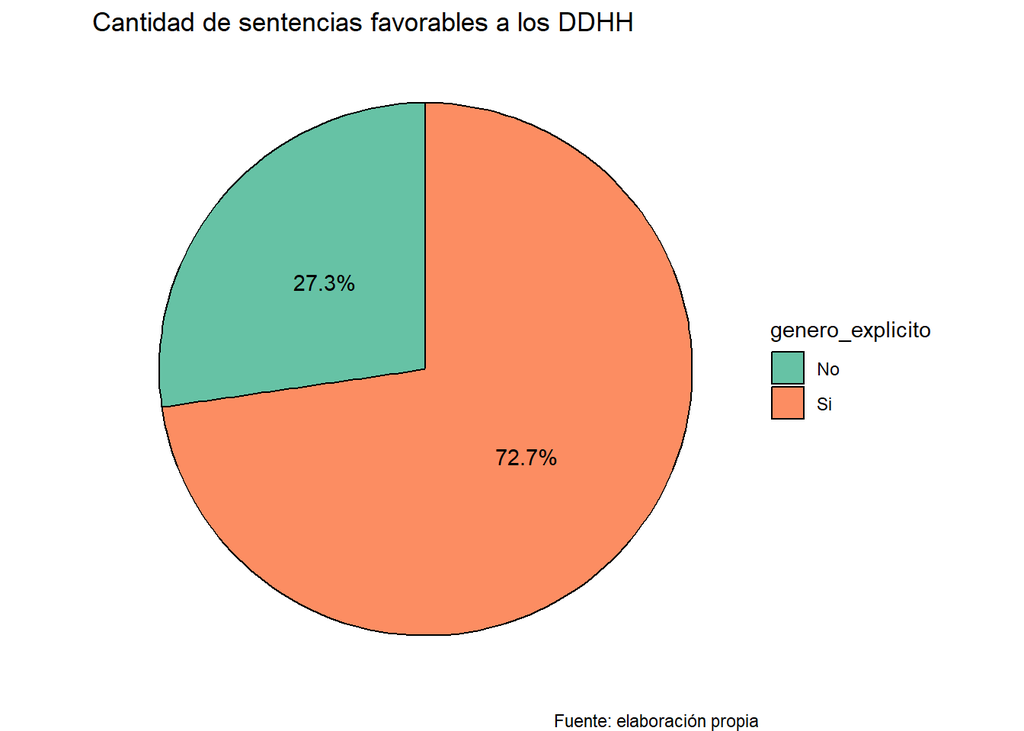

```r
base %>%
  filter(orientacion_decision == "A favor de los DDHH") %>%
  group_by(genero_explicito) %>%
  summarise(Cantidad = n()) %>%
  mutate(Porcentaje = (Cantidad / sum(Cantidad)) * 100) %>%
  ggplot(aes(x="", y=Cantidad, fill=genero_explicito, label=sprintf("%.1f%%", Porcentaje))) +
  geom_bar(stat="identity", width=1, color="black") +
  geom_text(position = position_stack(vjust = 0.5)) +
  coord_polar("y", start=0) +
  theme_void() +
  scale_fill_brewer(palette="Set2") +
  labs(x="", y="",
       title = "Cantidad de sentencias favorables a los DDHH",
       caption = "Fuente: elaboración propia")
```

¿Y qué pasa a la inversa? ¿Todos los casos que tienen perspectiva de género son a favor de los DDHH?

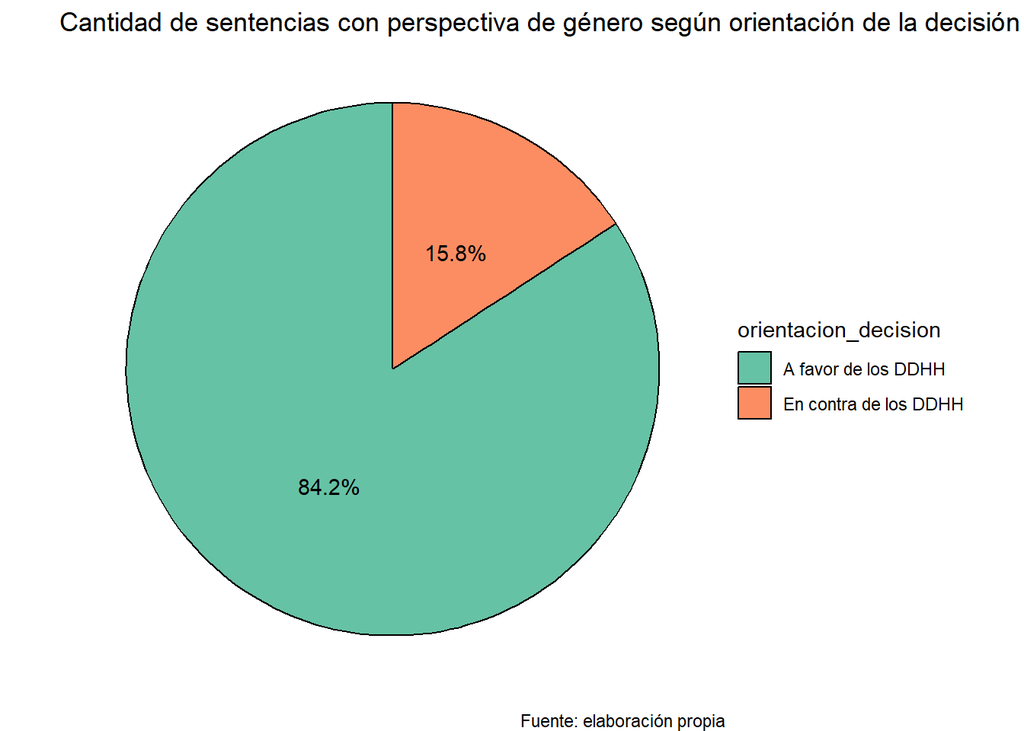

```r
base %>%
  filter(genero_explicito == "Si") %>%
  group_by(orientacion_decision) %>%
  summarise(Cantidad = n()) %>%
  mutate(Porcentaje = (Cantidad / sum(Cantidad)) * 100) %>%
  ggplot(aes(x="", y=Cantidad, fill=orientacion_decision, label=sprintf("%.1f%%", Porcentaje))) +
  geom_bar(stat="identity", width=1, color="black") +
  geom_text(position = position_stack(vjust = 0.5)) +
  coord_polar("y", start=0) +
  theme_void() +
  scale_fill_brewer(palette="Set2") +
  labs(x="", y="",
       title = "Cantidad de sentencias con perspectiva de género según orientación de la decisión",
       caption = "Fuente: elaboración propia")
```

## 1.15 Normativa internacional

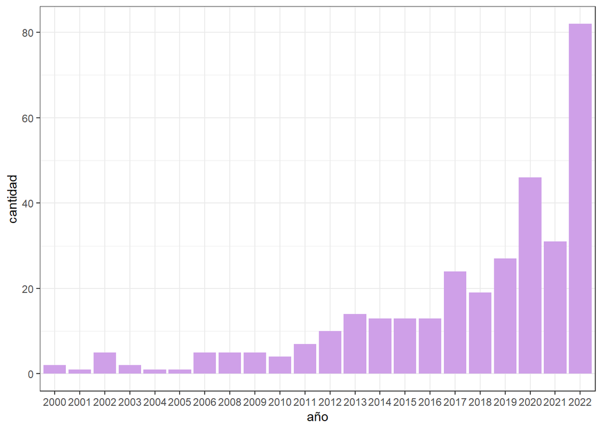

```r
base %>% mutate(año=substr(fecha, 1,4)) %>%
  group_by(año, instrumentos_internacionales) %>%
  summarise(cantidad = n()) %>%
  arrange(cantidad) %>%
  ggplot() +
  geom_col(aes(x=año, y=cantidad), fill = "#cfa0e8") +
  theme_bw()
```

# 2 Análisis por país

Ver si varían los temas, orientación decisión y argumentos

cargo base de datos con fecha de tratamiento

```r
fecha_inst <- read_excel("Fechas tratamiento.xlsx")

fecha_protocolo <- read_excel("Fechas tratamiento.xlsx", sheet = 2)
```

- Perspectiva de género

Porcentaje de casos con perspectiva de género según país - tabla

```r
base %>%
  group_by(pais, genero_explicito) %>%
  summarise(Cantidad = n()) %>%
  mutate(Porcentaje = round((Cantidad / sum(Cantidad)) * 100, digits = 2)) %>%
  filter(genero_explicito == "Si") %>%
  select(pais, Porcentaje) %>%
  kable() %>%
  kable_paper(bootstrap_options = "striped", full_width = F)
```

| pais | Porcentaje |
| --- | --- |
| Argentina | 51.28 |
| Chile | 67.06 |
| México | 79.07 |
| Perú | 63.64 |

## 2.1 Perú

```r
peru <- base %>%
  filter(pais == "Perú") %>%
  mutate(fecha_inst = "2016",
         fecha_protocolo = "2022",
         año=substr(fecha,1,4))

peru$año <- as.numeric(peru$año)
```

- Orientación decisión - general

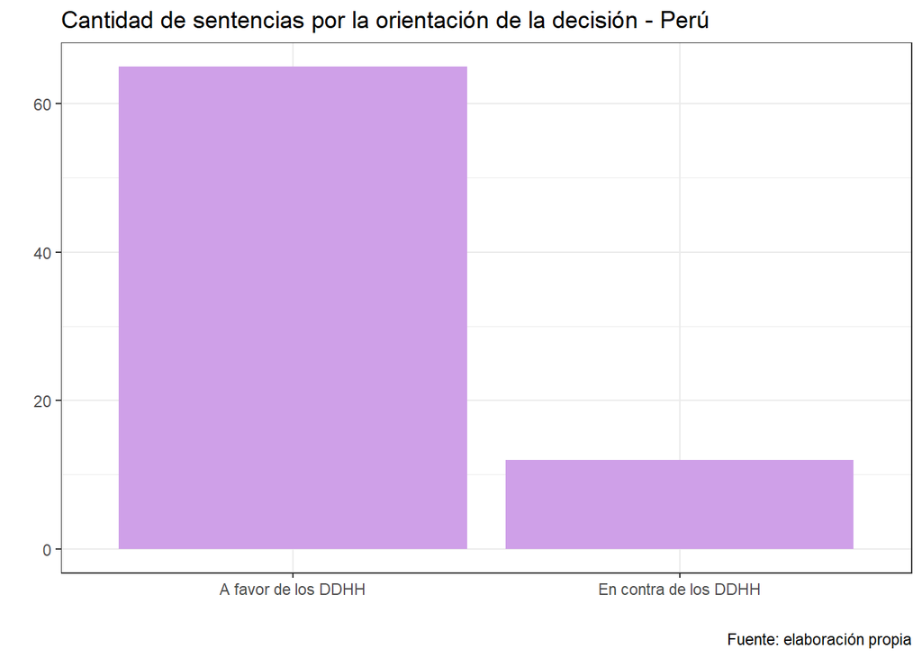

```r
peru %>%
  group_by(orientacion_decision) %>%
  summarise(Cantidad=n()) %>%
  ggplot(aes(x=reorder(orientacion_decision, -Cantidad), y=Cantidad)) +
  geom_col(fill = "#cfa0e8") +
  theme_bw() +
  labs(x="", y="",
       title = "Cantidad de sentencias por la orientación de la decisión - Perú",
       caption = "Fuente: elaboración propia")
```

- Orientación decisión - evolución

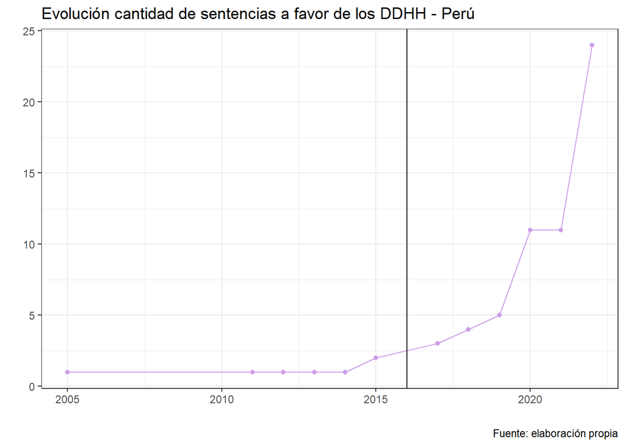

```r
peru %>%
  group_by(orientacion_decision, año) %>%
  summarise(Cantidad=n()) %>%
  filter(orientacion_decision == "A favor de los DDHH") %>%
  ggplot(aes(x=año, y=Cantidad)) +
  geom_point(color = "#cfa0e8") +
  geom_line(color = "#cfa0e8") +
  geom_vline(xintercept = 2016) +
  theme_bw() +
  labs(x="", y="",
       title = "Evolución cantidad de sentencias a favor de los DDHH - Perú",
       caption = "Fuente: elaboración propia")
```

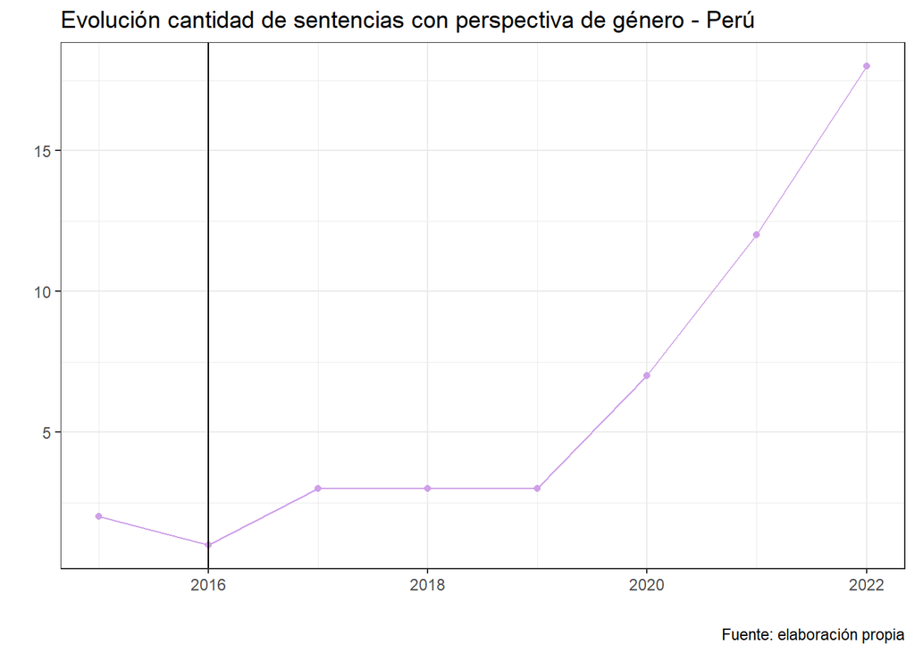

```r
peru %>%
  group_by(genero_explicito, año) %>%
  summarise(Cantidad=n()) %>%
  filter(genero_explicito == "Si") %>%
  ggplot(aes(x=año, y=Cantidad)) +
  geom_point(color = "#cfa0e8") +
  geom_line(color = "#cfa0e8") +
  geom_vline(xintercept = 2016) +
  theme_bw() +
  labs(x="", y="",
       title = "Evolución cantidad de sentencias con perspectiva de género - Perú",
       caption = "Fuente: elaboración propia")
```

- Dimension

- Remedios
- Descripción caso promedio

*ex ante y ex post del tratamiento sobre las partes, la dimensión, perspectiva de género, remedio y orientación decisión*

```r
peru <- peru %>%
  mutate(grupo = ifelse(año < 2016, "Pre", "Post"))

peru %>%
  group_by(grupo) %>%
  summarize(
    dimension_mas_frecuente = names(sort(table(dimension), decreasing = TRUE))[1],
    orientacion_decision_mas_frecuente = names(sort(table(orientacion_decision), decreasing = TRUE))[1],
    genero_explicito_mas_frecuente = names(sort(table(genero_explicito), decreasing = TRUE))[1],
    caracter_remedio_mas_frecuente = names(sort(table(caracter_remedio), decreasing = TRUE))[1],
    tipocaso_mas_frecuente = names(sort(table(tipo_caso), decreasing = TRUE))[1]
  ) %>%
  kable() %>%
  kable_paper(bootstrap_options = "striped", full_width = F)
```

| grupo | dimension_mas_frecuente | orientacion_decision_mas_frecuente | genero_explicito_mas_frecuente | caracter_remedio_mas_frecuente | tipocaso_mas_frecuente |
| --- | --- | --- | --- | --- | --- |
| Post | Violencia por motivos de géneros | A favor de los DDHH | Si | Individual | Individual |
| Pre | Violencia por motivos de géneros | A favor de los DDHH | No | Individual | Individual |

```r
# Porcentajes
# casos orientación decisión
peru %>% group_by(grupo, orientacion_decision) %>%
  summarise(cantidad = n()) %>%
  mutate(porcentaje = cantidad/sum(cantidad)*100) %>%
  kable() %>%
  kable_paper(bootstrap_options = "striped", full_width = F)
```

| grupo | orientacion_decision | cantidad | porcentaje |
| --- | --- | --- | --- |
| Post | A favor de los DDHH | 58 | 85.29412 |
| Post | En contra de los DDHH | 10 | 14.70588 |
| Pre | A favor de los DDHH | 7 | 77.77778 |
| Pre | En contra de los DDHH | 2 | 22.22222 |

```r
# casos género explícito
peru %>% group_by(grupo, genero_explicito) %>%
  summarise(cantidad = n()) %>%
  mutate(porcentaje = cantidad/sum(cantidad)*100) %>%
  kable() %>%
  kable_paper(bootstrap_options = "striped", full_width = F)
```

| grupo | genero_explicito | cantidad | porcentaje |
| --- | --- | --- | --- |
| Post | No | 21 | 30.88235 |
| Post | Si | 47 | 69.11765 |
| Pre | No | 7 | 77.77778 |
| Pre | Si | 2 | 22.22222 |

```r
# casos carácter remedio
peru %>% group_by(grupo, caracter_remedio) %>%
  summarise(cantidad = n()) %>%
  mutate(porcentaje = cantidad/sum(cantidad)*100) %>%
  kable() %>%
  kable_paper(bootstrap_options = "striped", full_width = F)
```

| grupo | caracter_remedio | cantidad | porcentaje |
| --- | --- | --- | --- |
| Post | Colectivo | 1 | 1.470588 |
| Post | Estructural | 1 | 1.470588 |
| Post | Individual | 65 | 95.588235 |
| Post | NA | 1 | 1.470588 |
| Pre | Estructural | 2 | 22.222222 |
| Pre | Individual | 7 | 77.777778 |

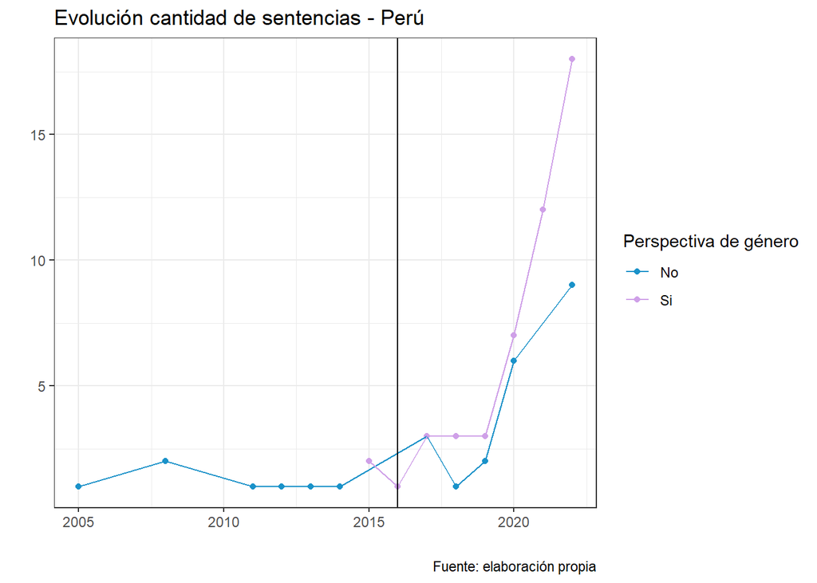

```r
tabla_peru <- peru %>%
  group_by(año,genero_explicito) %>%
  summarise(Cantidad=n())

tabla_peru %>%
  ggplot(aes(x=año, y=Cantidad, color=genero_explicito)) +
  geom_point() +
  geom_line() +
  geom_vline(xintercept = 2016) +
  theme_bw() +
  labs(x="", y="",
       title = "Evolución cantidad de sentencias - Perú",
       caption = "Fuente: elaboración propia") +
  scale_color_manual(values = c("#1a92c9","#cfa0e8"), name = "Perspectiva de género")
```

## 2.2 México

```r
mex <- base %>%
  filter(pais == "México") %>%
  mutate(fecha_inst = "2010",
         fecha_protocolo = "2013",
         año=substr(fecha,1,4))

mex$año <- as.numeric(mex$año)
```

- Orientación decisión

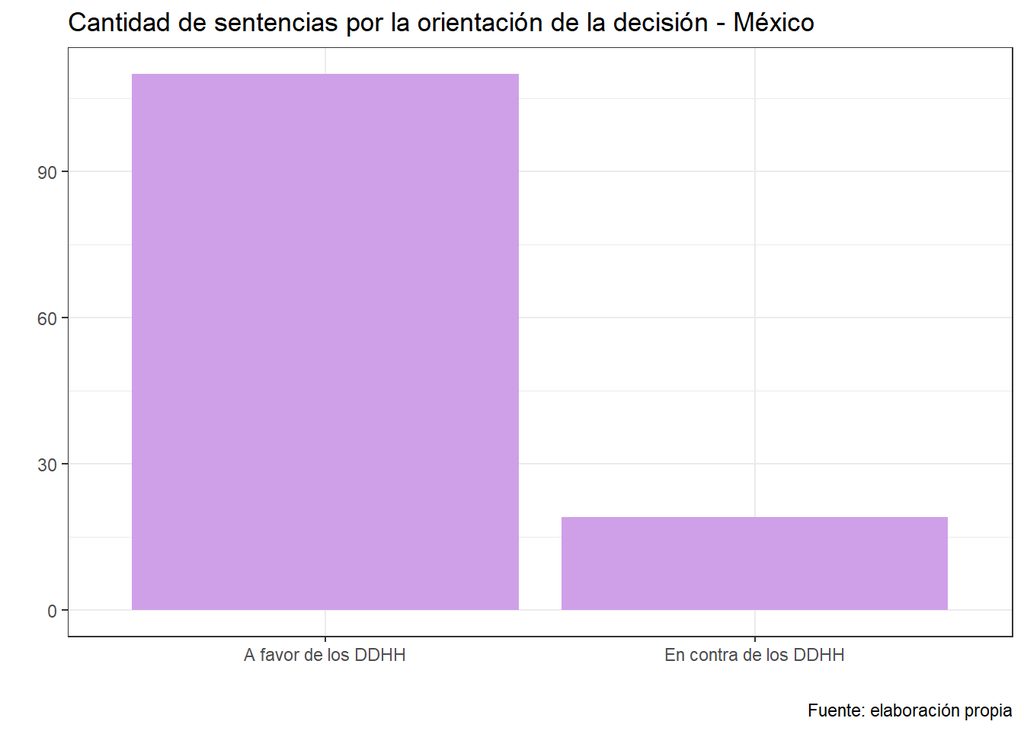

```r
mex %>%
  group_by(orientacion_decision) %>%
  summarise(Cantidad=n()) %>%
  ggplot(aes(x=reorder(orientacion_decision, -Cantidad), y=Cantidad)) +
  geom_col(fill = "#cfa0e8") +
  theme_bw() +
  labs(x="", y="",
       title = "Cantidad de sentencias por la orientación de la decisión - México",
       caption = "Fuente: elaboración propia")
```

- Orientación decisión - evolución

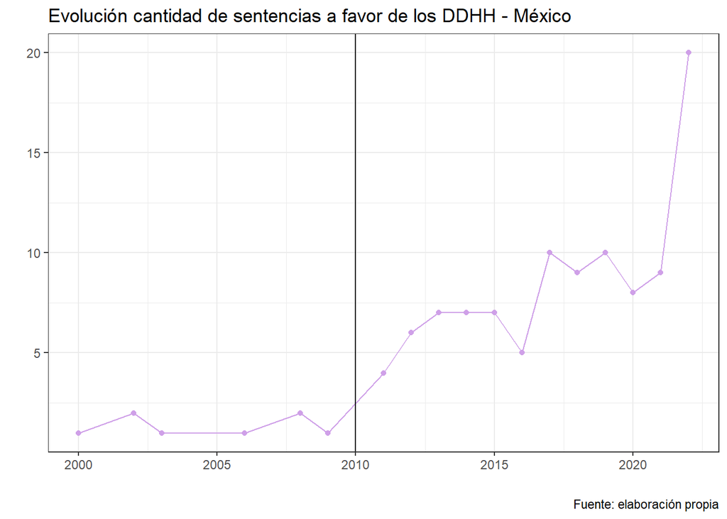

```r
mex %>%
  group_by(orientacion_decision, año) %>%
  summarise(Cantidad=n()) %>%
  filter(orientacion_decision == "A favor de los DDHH") %>%
  ggplot(aes(x=año, y=Cantidad)) +
  geom_point(color = "#cfa0e8") +
  geom_line(color = "#cfa0e8") +
  geom_vline(xintercept = 2010) +
  theme_bw() +
  labs(x="", y="",
       title = "Evolución cantidad de sentencias a favor de los DDHH - México",
       caption = "Fuente: elaboración propia")
```

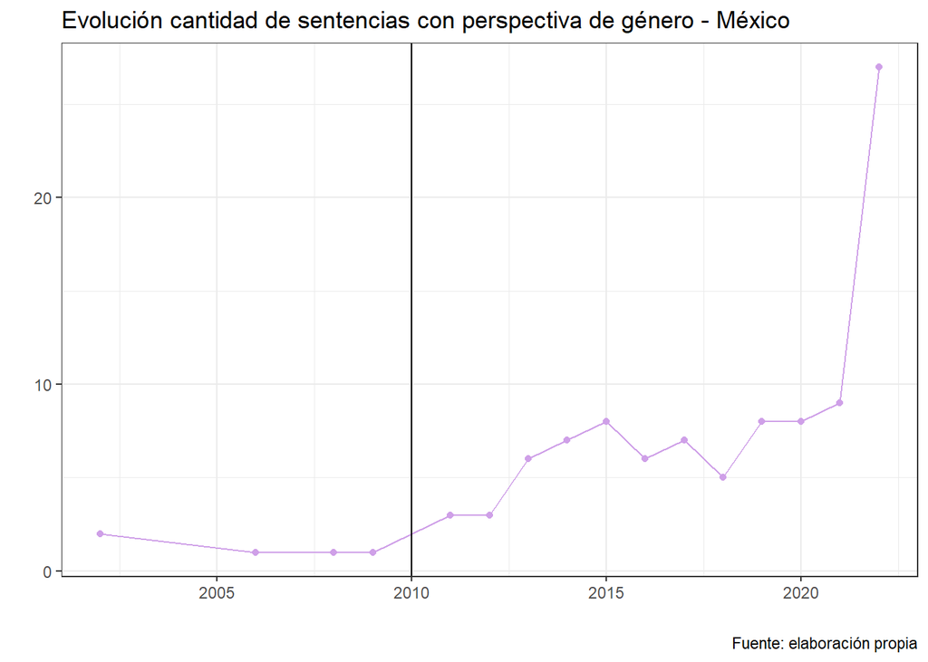

```r
mex %>%
  group_by(genero_explicito, año) %>%
  summarise(Cantidad=n()) %>%
  filter(genero_explicito == "Si") %>%
  ggplot(aes(x=año, y=Cantidad)) +
  geom_point(color = "#cfa0e8") +
  geom_line(color = "#cfa0e8") +
  geom_vline(xintercept = 2010) +
  theme_bw() +
  labs(x="", y="",
       title = "Evolución cantidad de sentencias con perspectiva de género - México",
       caption = "Fuente: elaboración propia")
```

```r
mex <- mex %>%
  mutate(grupo = ifelse(año < 2010, "Pre", "Post"))

mex %>%
  group_by(grupo) %>%
  summarize(
    dimension_mas_frecuente = names(sort(table(dimension), decreasing = TRUE))[1],
    orientacion_decision_mas_frecuente = names(sort(table(orientacion_decision), decreasing = TRUE))[1],
    genero_explicito_mas_frecuente = names(sort(table(genero_explicito), decreasing = TRUE))[1],
    caracter_remedio_mas_frecuente = names(sort(table(caracter_remedio), decreasing = TRUE))[1],
    tipocaso_mas_frecuente = names(sort(table(tipo_caso), decreasing = TRUE))[1]
  ) %>%
  kable() %>%
  kable_paper(bootstrap_options = "striped", full_width = F)
```

| grupo | dimension_mas_frecuente | orientacion_decision_mas_frecuente | genero_explicito_mas_frecuente | caracter_remedio_mas_frecuente | tipocaso_mas_frecuente |
| --- | --- | --- | --- | --- | --- |
| Post | Derechos Sexuales y Reproductivos | A favor de los DDHH | Si | Individual | Individual |
| Pre | Derechos Sexuales y Reproductivos | A favor de los DDHH | No | Estructural | Individual |

```r
# Porcentajes
# casos orientación decisión
mex %>% group_by(grupo, orientacion_decision) %>%
  summarise(cantidad = n()) %>%
  mutate(porcentaje = cantidad/sum(cantidad)*100) %>%
  kable() %>%
  kable_paper(bootstrap_options = "striped", full_width = F)
```

| grupo | orientacion_decision | cantidad | porcentaje |
| --- | --- | --- | --- |
| Post | A favor de los DDHH | 102 | 85.71429 |
| Post | En contra de los DDHH | 17 | 14.28571 |
| Pre | A favor de los DDHH | 8 | 80.00000 |
| Pre | En contra de los DDHH | 2 | 20.00000 |

```r
# casos género explícito
mex %>% group_by(grupo, genero_explicito) %>%
  summarise(cantidad = n()) %>%
  mutate(porcentaje = cantidad/sum(cantidad)*100) %>%
  kable() %>%
  kable_paper(bootstrap_options = "striped", full_width = F)
```

| grupo | genero_explicito | cantidad | porcentaje |
| --- | --- | --- | --- |
| Post | No | 22 | 18.48739 |
| Post | Si | 97 | 81.51260 |
| Pre | No | 5 | 50.00000 |
| Pre | Si | 5 | 50.00000 |

```r
# casos carácter remedio
mex %>% group_by(grupo, caracter_remedio) %>%
  summarise(cantidad = n()) %>%
  mutate(porcentaje = cantidad/sum(cantidad)*100) %>%
  kable() %>%
  kable_paper(bootstrap_options = "striped", full_width = F)
```

| grupo | caracter_remedio | cantidad | porcentaje |
| --- | --- | --- | --- |
| Post | Colectivo | 15 | 12.605042 |
| Post | Estructural | 24 | 20.168067 |
| Post | Individual | 75 | 63.025210 |
| Post | NA | 5 | 4.201681 |
| Pre | Colectivo | 2 | 20.000000 |
| Pre | Estructural | 4 | 40.000000 |
| Pre | Individual | 3 | 30.000000 |
| Pre | NA | 1 | 10.000000 |

¿Cómo evolucionan los remedios colectivos y estructurales en México? ¿Hubo un cambio a partir de los protocolos?

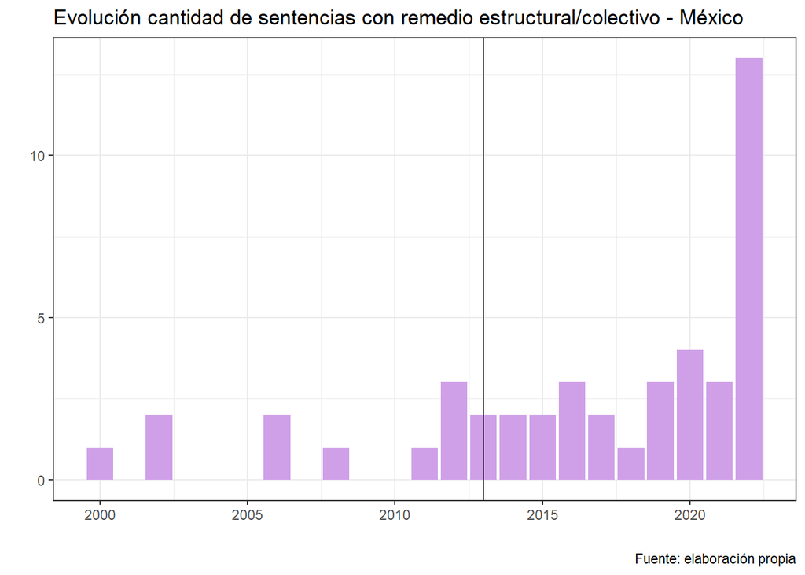

```r
mex %>%
  filter(caracter_remedio %in% c("Colectivo", "Estructural")) %>%
  ggplot(aes(x=año)) +
  geom_bar(fill = "#cfa0e8") +
  geom_vline(xintercept = 2013) +
  theme_bw() +
  labs(x="", y="",
       title = "Evolución cantidad de sentencias con remedio estructural/colectivo - México",
       caption = "Fuente: elaboración propia")
```

Tabla que agrupe por año genero_explicito

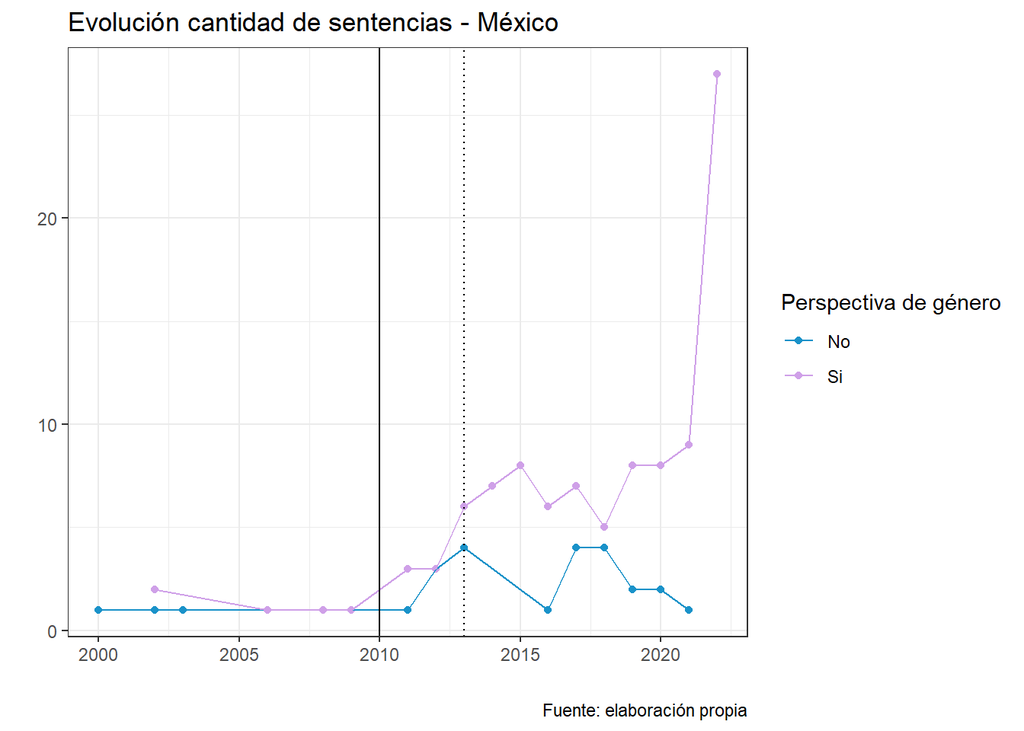

```r
tabla_mex <- mex %>%
  group_by(año,genero_explicito) %>%
  summarise(Cantidad=n())

tabla_mex %>%
  ggplot(aes(x=año, y=Cantidad, color=genero_explicito)) +
  geom_point() +
  geom_line() +
  geom_vline(xintercept = 2010) +
  geom_vline(xintercept = 2013, linetype="dotted") +
  theme_bw() +
  labs(x="", y="",
       title = "Evolución cantidad de sentencias - México",
       caption = "Fuente: elaboración propia") +
  scale_color_manual(values = c("#1a92c9","#cfa0e8"), name = "Perspectiva de género")
```

## 2.3 Chile

```r
chile <- base %>%
  filter(pais == "Chile") %>%
  mutate(fecha_inst = "2016",
         fecha_protocolo = "2018",
         año=substr(fecha,1,4))

chile$año <- as.numeric(chile$año)
```

- Orientación decisión

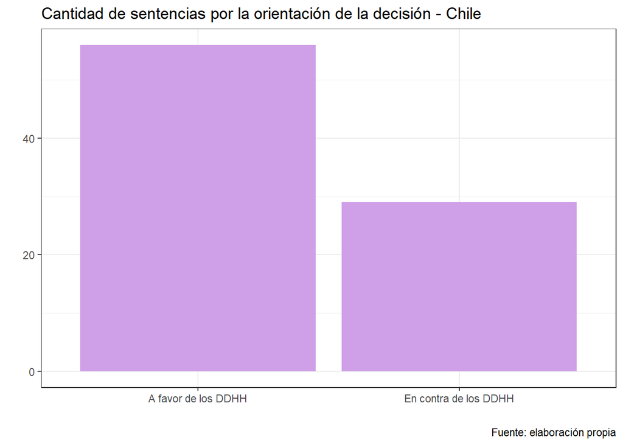

```r
chile %>%
  group_by(orientacion_decision) %>%
  summarise(Cantidad=n()) %>%
  ggplot(aes(x=reorder(orientacion_decision, -Cantidad), y=Cantidad)) +
  geom_col(fill = "#cfa0e8") +
  theme_bw() +
  labs(x="", y="",
       title = "Cantidad de sentencias por la orientación de la decisión - Chile",
       caption = "Fuente: elaboración propia")
```

- Orientación decisión - evolución

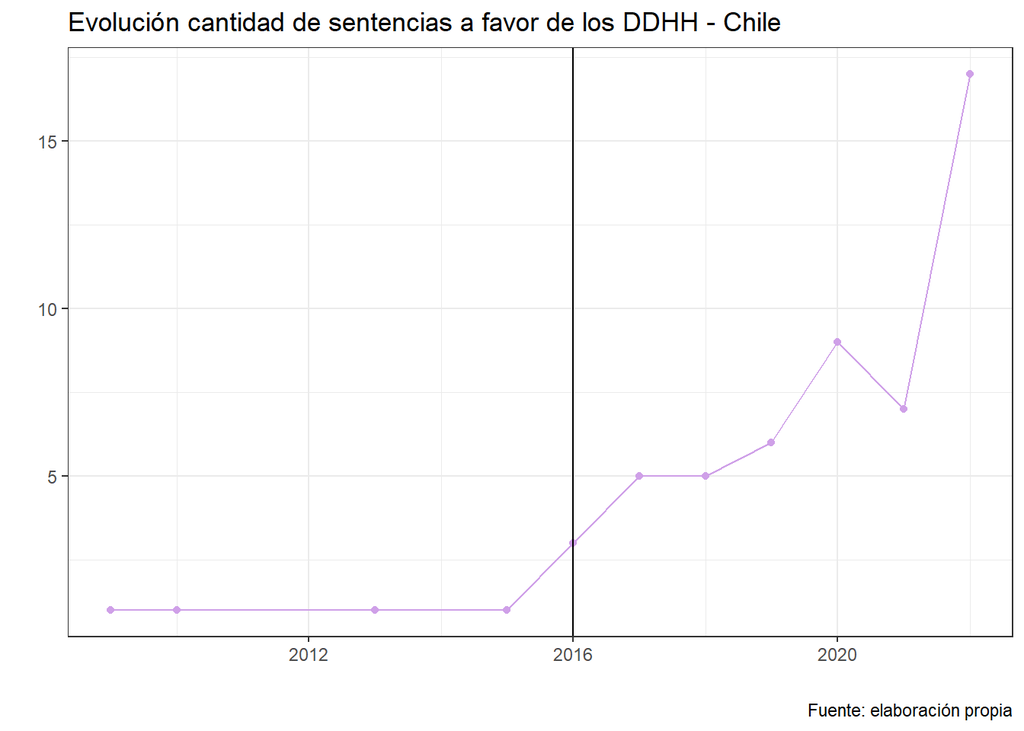

```r
chile %>%
  group_by(orientacion_decision, año) %>%
  summarise(Cantidad=n()) %>%
  filter(orientacion_decision == "A favor de los DDHH") %>%
  ggplot(aes(x=año, y=Cantidad)) +
  geom_point(color = "#cfa0e8") +
  geom_line(color = "#cfa0e8") +
  geom_vline(xintercept = 2016) +
  theme_bw() +
  labs(x="", y="",
       title = "Evolución cantidad de sentencias a favor de los DDHH - Chile",
       caption = "Fuente: elaboración propia")
```

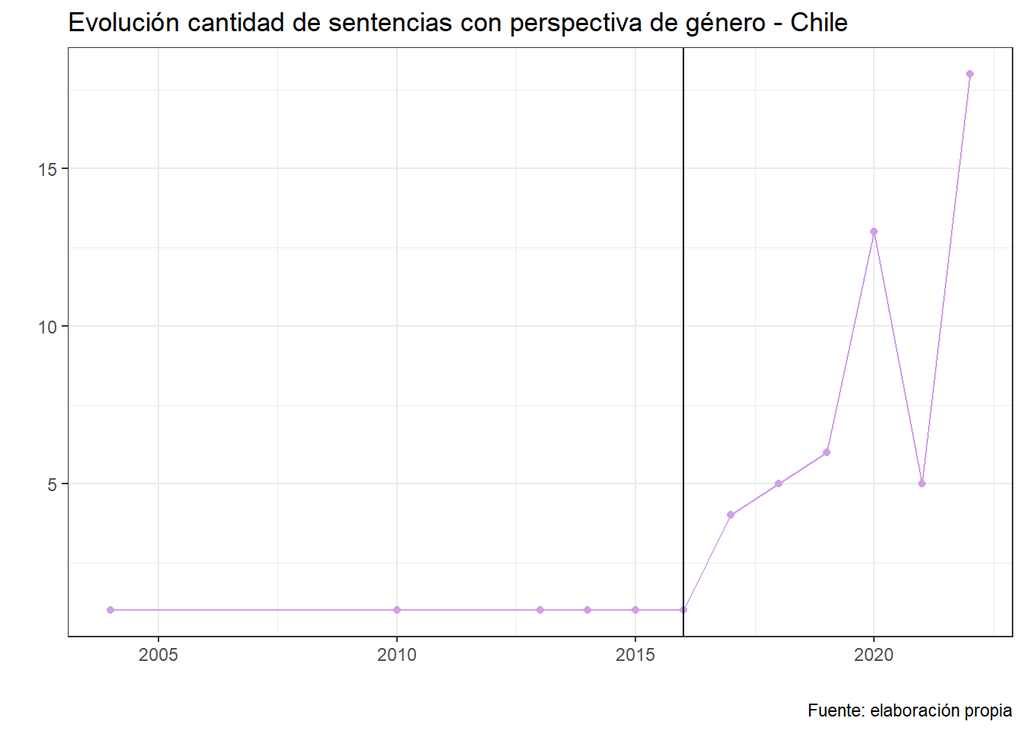

```r
chile %>%
  group_by(genero_explicito, año) %>%
  summarise(Cantidad=n()) %>%
  filter(genero_explicito == "Si") %>%
  ggplot(aes(x=año, y=Cantidad)) +
  geom_point(color = "#cfa0e8") +
  geom_line(color = "#cfa0e8") +
  geom_vline(xintercept = 2016) +
  theme_bw() +
  labs(x="", y="",
       title = "Evolución cantidad de sentencias con perspectiva de género - Chile",
       caption = "Fuente: elaboración propia")
```

```r
chile <- chile %>%
  mutate(grupo = ifelse(año < 2016, "Pre", "Post"))

chile %>%
  group_by(grupo) %>%
  summarize(
    dimension_mas_frecuente = names(sort(table(dimension), decreasing = TRUE))[1],
    orientacion_decision_mas_frecuente = names(sort(table(orientacion_decision), decreasing = TRUE))[1],
    genero_explicito_mas_frecuente = names(sort(table(genero_explicito), decreasing = TRUE))[1],
    caracter_remedio_mas_frecuente = names(sort(table(caracter_remedio), decreasing = TRUE))[1],
    tipocaso_mas_frecuente = names(sort(table(tipo_caso), decreasing = TRUE))[1]
  ) %>%
  kable() %>%
  kable_paper(bootstrap_options = "striped", full_width = F)
```

| grupo | dimension_mas_frecuente | orientacion_decision_mas_frecuente | genero_explicito_mas_frecuente | caracter_remedio_mas_frecuente | tipocaso_mas_frecuente |
| --- | --- | --- | --- | --- | --- |
| Post | Violencia por motivos de géneros | A favor de los DDHH | Si | Individual | Individual |
| Pre | Trabajo y Protección Social | En contra de los DDHH | No | Individual | Individual |

```r
# Porcentajes
# casos orientación decisión
chile %>% group_by(grupo, orientacion_decision) %>%
  summarise(cantidad = n()) %>%
  mutate(porcentaje = cantidad/sum(cantidad)*100) %>%
  kable() %>%
  kable_paper(bootstrap_options = "striped", full_width = F)
```

| grupo | orientacion_decision | cantidad | porcentaje |
| --- | --- | --- | --- |
| Post | A favor de los DDHH | 52 | 73.23944 |
| Post | En contra de los DDHH | 19 | 26.76056 |
| Pre | A favor de los DDHH | 4 | 28.57143 |
| Pre | En contra de los DDHH | 10 | 71.42857 |

```r
# casos género explícito
chile %>% group_by(grupo, genero_explicito) %>%
  summarise(cantidad = n()) %>%
  mutate(porcentaje = cantidad/sum(cantidad)*100) %>%
  kable() %>%
  kable_paper(bootstrap_options = "striped", full_width = F)
```

| grupo | genero_explicito | cantidad | porcentaje |
| --- | --- | --- | --- |
| Post | No | 19 | 26.76056 |
| Post | Si | 52 | 73.23944 |
| Pre | No | 9 | 64.28571 |
| Pre | Si | 5 | 35.71429 |

```r
# casos carácter remedio
chile %>% group_by(grupo, caracter_remedio) %>%
  summarise(cantidad = n()) %>%
  mutate(porcentaje = cantidad/sum(cantidad)*100) %>%
  kable() %>%
  kable_paper(bootstrap_options = "striped", full_width = F)
```

| grupo | caracter_remedio | cantidad | porcentaje |
| --- | --- | --- | --- |
| Post | Colectivo | 1 | 1.408451 |
| Post | Individual | 70 | 98.591549 |
| Pre | Individual | 14 | 100.000000 |

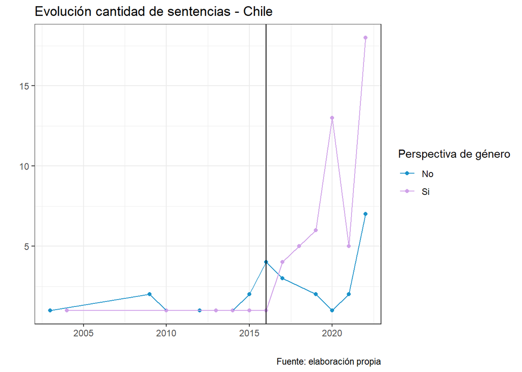

```r
tabla_chile <- chile %>%
  group_by(año,genero_explicito) %>%
  summarise(Cantidad=n())

tabla_chile %>%
  ggplot(aes(x=año, y=Cantidad, color=genero_explicito)) +
  geom_point() +
  geom_line() +
  geom_vline(xintercept = 2016) +
  theme_bw() +
  labs(x="", y="",
       title = "Evolución cantidad de sentencias - Chile",
       caption = "Fuente: elaboración propia") +
  scale_color_manual(values = c("#1a92c9","#cfa0e8"), name = "Perspectiva de género")
```

## 2.4 Argentina

```r
arg <- base %>%
  filter(pais == "Argentina") %>%
  mutate(fecha_inst = "2009",
         año=substr(fecha,1,4))

arg$año <- as.numeric(arg$año)
```

- Orientación decisión

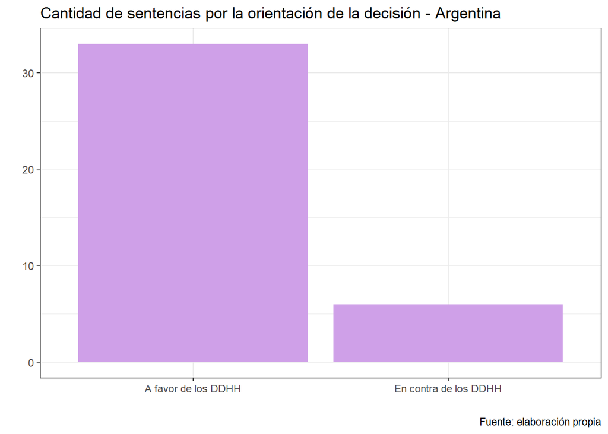

```r
arg %>%
  group_by(orientacion_decision) %>%
  summarise(Cantidad=n()) %>%
  ggplot(aes(x=reorder(orientacion_decision, -Cantidad), y=Cantidad)) +
  geom_col(fill = "#cfa0e8") +
  theme_bw() +
  labs(x="", y="",
       title = "Cantidad de sentencias por la orientación de la decisión - Argentina",
       caption = "Fuente: elaboración propia")
```

- Orientación decisión - evolución

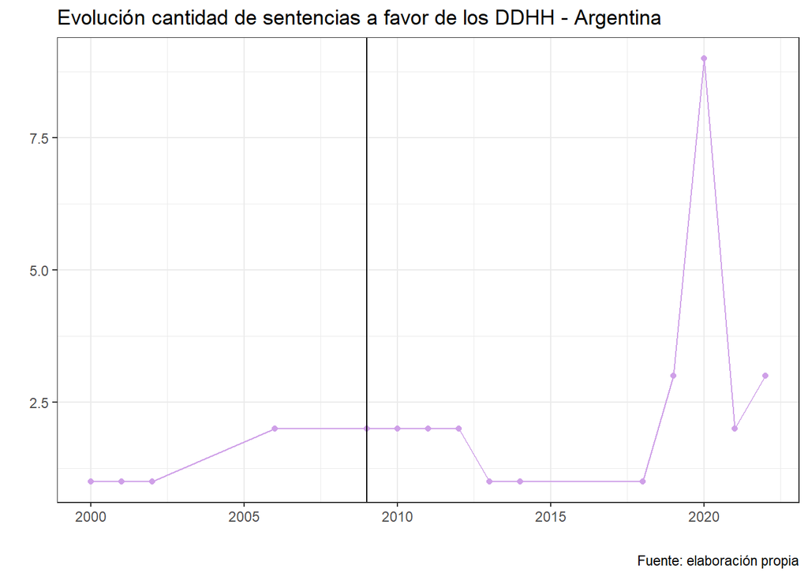

```r
arg %>%
  group_by(orientacion_decision, año) %>%
  summarise(Cantidad=n()) %>%
  filter(orientacion_decision == "A favor de los DDHH") %>%
  ggplot(aes(x=año, y=Cantidad)) +
  geom_point(color = "#cfa0e8") +
  geom_line(color = "#cfa0e8") +
  geom_vline(xintercept = 2009) +
  theme_bw() +
  labs(x="", y="",
       title = "Evolución cantidad de sentencias a favor de los DDHH - Argentina",
       caption = "Fuente: elaboración propia")
```

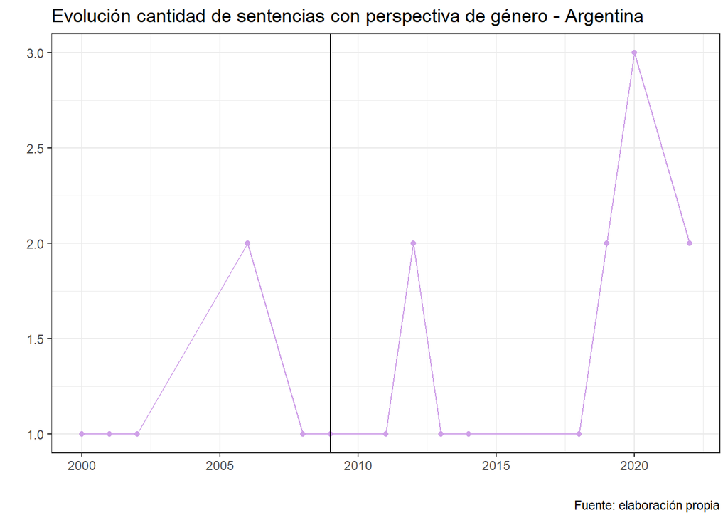

```r
arg %>%
  group_by(genero_explicito, año) %>%
  summarise(Cantidad=n()) %>%
  filter(genero_explicito == "Si") %>%
  ggplot(aes(x=año, y=Cantidad)) +
  geom_point(color = "#cfa0e8") +
  geom_line(color = "#cfa0e8") +
  geom_vline(xintercept = 2009) +
  theme_bw() +
  labs(x="", y="",
       title = "Evolución cantidad de sentencias con perspectiva de género - Argentina",
       caption = "Fuente: elaboración propia")
```

```r
arg <- arg %>%
  mutate(grupo = ifelse(año < 2009, "Pre", "Post"))

arg %>%
  group_by(grupo) %>%
  summarize(
    dimension_mas_frecuente = names(sort(table(dimension), decreasing = TRUE))[1],
    orientacion_decision_mas_frecuente = names(sort(table(orientacion_decision), decreasing = TRUE))[1],
    genero_explicito_mas_frecuente = names(sort(table(genero_explicito), decreasing = TRUE))[1],
    caracter_remedio_mas_frecuente = names(sort(table(caracter_remedio), decreasing = TRUE))[1],
    tipocaso_mas_frecuente = names(sort(table(tipo_caso), decreasing = TRUE))[1]
  ) %>%
  kable() %>%
  kable_paper(bootstrap_options = "striped", full_width = F)
```

| grupo | dimension_mas_frecuente | orientacion_decision_mas_frecuente | genero_explicito_mas_frecuente | caracter_remedio_mas_frecuente | tipocaso_mas_frecuente |
| --- | --- | --- | --- | --- | --- |
| Post | Violencia por motivos de géneros | A favor de los DDHH | No | Individual | Individual |
| Pre | Derechos Sexuales y Reproductivos | A favor de los DDHH | Si | Individual | Individual |

```r
# Porcentajes
# casos orientación decisión
arg %>% group_by(grupo, orientacion_decision) %>%
  summarise(cantidad = n()) %>%
  mutate(porcentaje = cantidad/sum(cantidad)*100) %>%
  kable() %>%
  kable_paper(bootstrap_options = "striped", full_width = F)
```

| grupo | orientacion_decision | cantidad | porcentaje |
| --- | --- | --- | --- |
| Post | A favor de los DDHH | 28 | 90.322581 |
| Post | En contra de los DDHH | 3 | 9.677419 |
| Pre | A favor de los DDHH | 5 | 62.500000 |
| Pre | En contra de los DDHH | 3 | 37.500000 |

```r
# casos género explícito
arg %>% group_by(grupo, genero_explicito) %>%
  summarise(cantidad = n()) %>%
  mutate(porcentaje = cantidad/sum(cantidad)*100) %>%
  kable() %>%
  kable_paper(bootstrap_options = "striped", full_width = F)
```

| grupo | genero_explicito | cantidad | porcentaje |
| --- | --- | --- | --- |
| Post | No | 17 | 54.83871 |
| Post | Si | 14 | 45.16129 |
| Pre | No | 2 | 25.00000 |
| Pre | Si | 6 | 75.00000 |

```r
# casos carácter remedio
arg %>% group_by(grupo, caracter_remedio) %>%
  summarise(cantidad = n()) %>%
  mutate(porcentaje = cantidad/sum(cantidad)*100) %>%
  kable() %>%
  kable_paper(bootstrap_options = "striped", full_width = F)
```

| grupo | caracter_remedio | cantidad | porcentaje |
| --- | --- | --- | --- |
| Post | Colectivo | 1 | 3.225807 |
| Post | Estructural | 1 | 3.225807 |
| Post | Individual | 29 | 93.548387 |
| Pre | Colectivo | 2 | 25.000000 |
| Pre | Individual | 6 | 75.000000 |

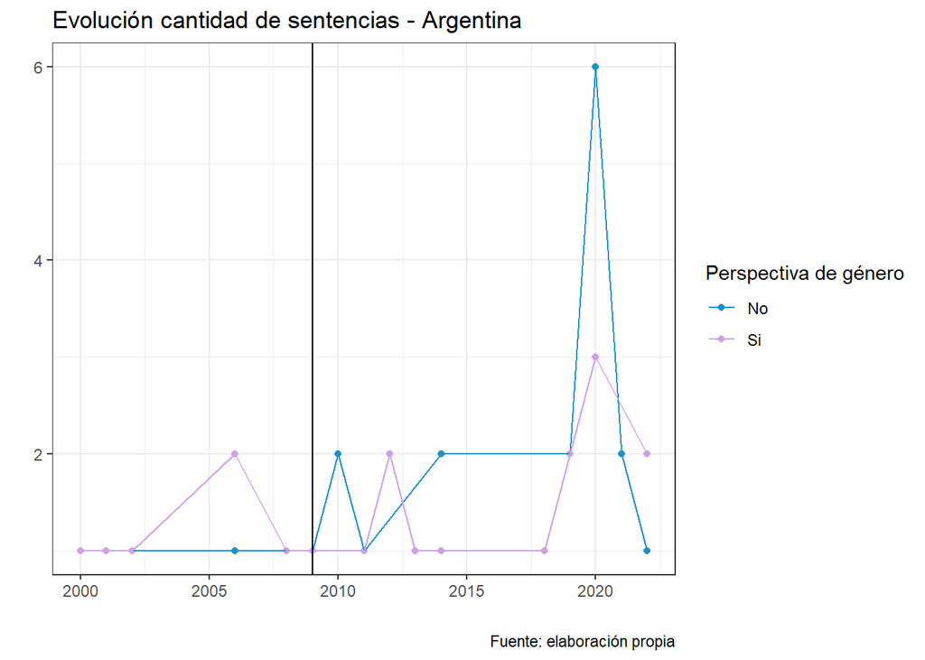

```r
tabla_arg <- arg %>%
  group_by(año,genero_explicito) %>%
  summarise(Cantidad=n())

tabla_arg %>%
  ggplot(aes(x=año, y=Cantidad, color=genero_explicito)) +
  geom_point() +
  geom_line() +
  geom_vline(xintercept = 2009) +
  theme_bw() +
  labs(x="", y="",
       title = "Evolución cantidad de sentencias - Argentina",
       caption = "Fuente: elaboración propia") +
  scale_color_manual(values = c("#1a92c9","#cfa0e8"), name = "Perspectiva de género")
```

## 2.5 Cantidad de sentencias buscador

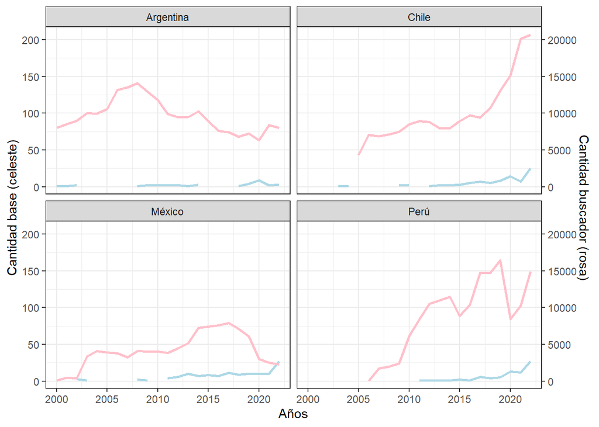

```r
cant_casos_total <- read_excel("Fechas tratamiento.xlsx", sheet = 3) %>%
  pivot_longer(cols = 2:5, names_to = "pais", values_to = "buscador")

cant_casos_base <- base %>% mutate(Años=year(fecha)) %>%
  group_by(Años, pais) %>% summarise(base=n())

cant_casos <- merge(cant_casos_base, cant_casos_total, all = T)

ggplot(cant_casos, aes(x=Años)) +
  geom_line(aes(y=base), color = "lightblue", size=1) +
  geom_line(aes(y=buscador/100), color = "pink", size=1) +
  facet_wrap(~pais) +
  theme_bw() +
  scale_y_continuous(name = "Cantidad base (celeste)",
                     sec.axis = sec_axis(trans=~.*100,
                                         name="Cantidad buscador (rosa)"))
```

Quiero ver ahora la correlación general

```r
cant_casos_clean <- cant_casos %>% na.omit()

cor_general <- cor(cant_casos_clean$base, cant_casos_clean$buscador)
print(paste("Correlación general:", cor_general))
```

```
## [1] "Correlación general: 0.186107478298224"
```

Y por país

```r
cor_pais <- cant_casos_clean %>%
  group_by(pais) %>%
  summarise(correlacion = cor(base, buscador))

print(cor_pais)
```

```
## # A tibble: 4 x 2
##   pais      correlacion
##   <chr>           <dbl>
## 1 Argentina      -0.347
## 2 Chile           0.815
## 3 México          0.137
## 4 Perú            0.313
```